# We Rate Dogs (@DogRates) : Insights & Visualizations

### This report revolves around the analysis of more than 2000 tweets on a twitter account ‘WeRateDogs’ (@dog_rates) which rates people's dogs with a humorous comments about the dog.

I started off with finding the most widely used application to post the tweets.

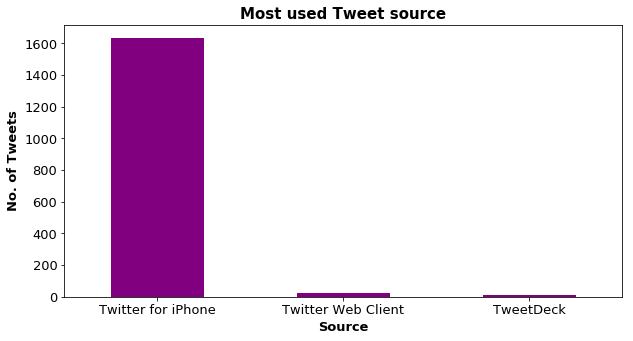

I plotted a bar graph that shows the no. of tweets posted via each source and it clearly shows that most tweets has been posted via Twitter for iPhone.

Then, I was curious to know what could be the most popular dog name in all these tweets, I though why not find the 10 most common dog names?

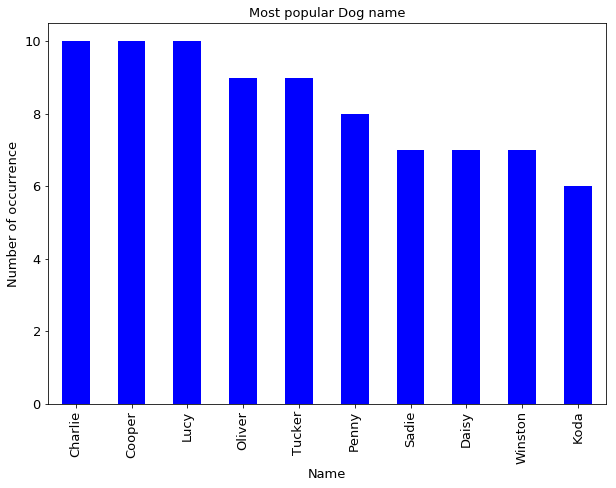

Upon plotting this data, I found out that Cooper, Lucy and Charlie are the most common dog names which have 10 others as the same name as them, followed by Oliver and Tucker.

[figure not shown]

Majority of the tweets were about Golden Retrievers which makes it the most popular dog on DogRates, followed by Labrador Retriever and Pembroke.

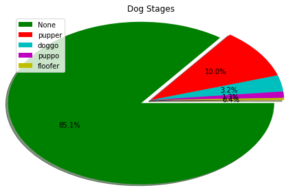

Then I went ahead to find the ost common dog stage using a pie chart, For 85% of the dogs, we didn't had the dog stage in the tweet information. Out of the remaining 15% dogs, most of the dogs were in pupper stage (10%), followed by duggo (3.2%), puppo (~1% )and floofer (<1%).